# Report on the Frequency and Impact of Bird-Aircraft Collisions in the US_2026_b

### H. OriginState - Feature

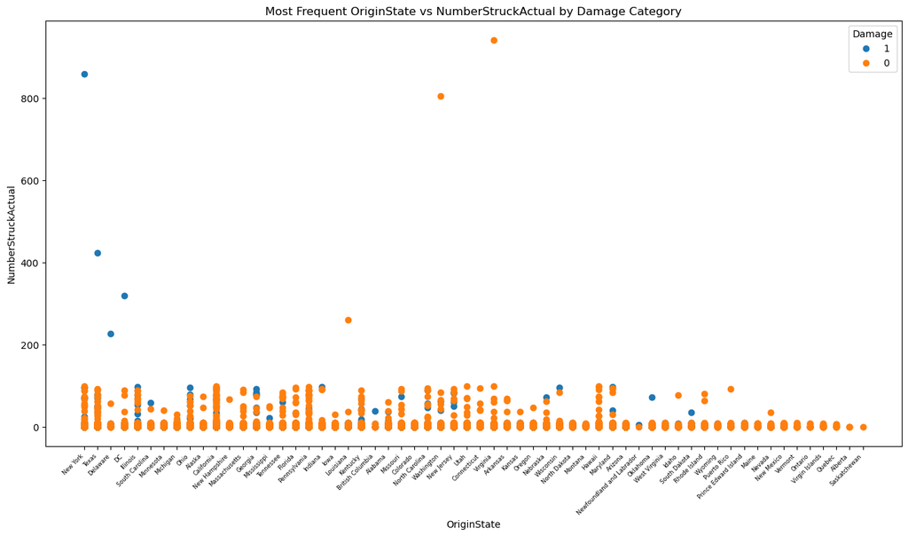

[interactive chart not shown]

```
Top 3 states with the highest incident counts:
OriginState
California    2499
Texas         2445
Florida       2045
Name: count, dtype: int64
```

#### Comments

1. California, Texas, and Florida are the states with more incidents compared to their countries.
2. It is fair to say that incidents have happened in all of U.S. territory.

### I. Cost - Feature

Note: "CostAsFloat" column was added above, on: 5. Data Quality Assessment: Outliers for analysis.

|  | RecordID | AircraftType | AirportName | AltitudeBin | MakeModel | NumberStruck | NumberStruckActual | Effect | FlightDate | Damage | ... | PilotWarned | Cost | Altitude | PeopleInjured | IsAircraftLarge? | CostAsFloat | FlightYear | NumberStruckBinned | Damage_label | Year_Damage |
| --- | --- | --- | --- | --- | --- | --- | --- | --- | --- | --- | --- | --- | --- | --- | --- | --- | --- | --- | --- | --- | --- |
| 0 | 202152 | Airplane | LAGUARDIA NY | (1000, 2000] | B-737-400 | Over 100 | 859 | Engine Shut Down | 2000-11-23 | 1 | ... | N | 30,736 | 1000-3000 | 0 | 1 | 30736.0 | 2000 | 10+ | Damage | 2000 \| Damage |
| 1 | 208159 | Airplane | DALLAS/FORT WORTH INTL ARPT | (-1, 0] | MD-80 | Over 100 | 424 | NaN | 2001-07-25 | 1 | ... | Y | 0 | NaN | 0 | 0 | 0.0 | 2001 | 10+ | Damage | 2001 \| Damage |
| 2 | 207601 | Airplane | LAKEFRONT AIRPORT | (30, 50] | C-500 | Over 100 | 261 | NaN | 2001-09-14 | 0 | ... | N | 0 | 0-1000 | 0 | 0 | 0.0 | 2001 | 10+ | No Damage | 2001 \| No Damage |
| 3 | 215953 | Airplane | SEATTLE-TACOMA INTL | (30, 50] | B-737-400 | Over 100 | 806 | Precautionary Landing | 2002-09-05 | 0 | ... | Y | 0 | 0-1000 | 0 | 1 | 0.0 | 2002 | 10+ | No Damage | 2002 \| No Damage |
| 4 | 219878 | Airplane | NORFOLK INTL | (30, 50] | CL-RJ100/200 | Over 100 | 942 | NaN | 2003-06-23 | 0 | ... | N | 0 | 0-1000 | 0 | 0 | 0.0 | 2003 | 10+ | No Damage | 2003 \| No Damage |

5 rows × 31 columns

Create a histogram to visualize the distribution of Cost

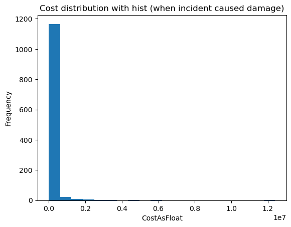

```
Top 5 highest values in CostAsFloat and corresponding 'PeopleInjured':
       CostAsFloat  PeopleInjured    WildlifeSpecies
232     12397751.0              2  White-tailed deer
4501     5704387.0              0       Canada goose
13796    5704387.0              0  White-tailed kite
23407    4570000.0              0         Bald eagle
291      3644483.0              0       Canada goose
```

##### Observations

1. Although there was one very costly incident, most are not as expensive
2. The most costly incident resulted in 2 people being injured. And it was not a collision against a bird.

#### **Trend**

The most costly incident involved 2 people being injured, but it was not related to a bird collision, indicating that the severity and cost of incidents may not always correlate with bird strikes.

Although the dataset is highly usable and provides valuable insights, there are some gaps that limit a deeper understanding of the trends. For example, we observed an increase in incident occurrences over time, but it's unclear whether this is due to the growing number of planes in operation, urban expansion pushing into bird habitats, or potential changes in aircraft engine design.

While the data offers a strong foundation for analysis, it raises several questions that can only be answered with additional external data. Factors such as the number of aircraft, environmental changes, and even advancements in aviation technology could all influence the trends seen in this dataset. To fully comprehend the underlying causes and patterns, more comprehensive data will be needed to explore these variables in greater detail.

### J. PeopleInjured - Feature

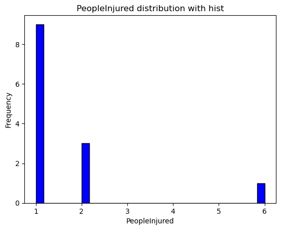

```
Number of people injured:  13
```

Exploring the incidents where people sustained injuries.

```
Total Incidents:  25429
There were 13 incidents in which people sustained injuries,
resulting in a total of 21 individuals injured.
```

|  | PeopleInjured | MakeModel | Engines | FlightPhase | WildlifeSize | WildlifeSpecies | ConditionsSky | Cost |
| --- | --- | --- | --- | --- | --- | --- | --- | --- |
| 4422 | 6 | LEARJET-24 | 2 | Climb | Small | Unknown bird - small | No Cloud | 926,070 |
| 232 | 2 | LEARJET-60 | 2 | Landing Roll | Large | White-tailed deer | No Cloud | 12,397,751 |
| 7180 | 2 | C-172 | 1 | Descent | Large | Turkey vulture | Some Cloud | 1,382 |
| 24879 | 2 | MAULE M-7 | 1 | Climb | Medium | Ducks | No Cloud | 14,000 |
| 780 | 1 | DHC8 DASH 8 | 2 | Approach | Medium | Lesser scaup | No Cloud | 123,476 |
| 2636 | 1 | CIRRUS SR 20/22 | 1 | Climb | Medium | Anhinga | Overcast | 0 |
| 2779 | 1 | C-402 | 2 | Climb | Large | Black vulture | Some Cloud | 0 |
| 5822 | 1 | BE-95 | 2 | Approach | Large | Black vulture | No Cloud | 26,553 |
| 7047 | 1 | C-172 | 1 | Approach | Large | Turkey vulture | No Cloud | 570 |
| 8453 | 1 | PA-60 601 | 2 | Climb | Large | Black vulture | No Cloud | 9,878 |
| 12250 | 1 | C-210 CENTUR | 1 | Approach | Large | Black vulture | No Cloud | 0 |
| 16114 | 1 | C-172 | 1 | Approach | Large | Black vulture | No Cloud | 0 |
| 17066 | 1 | ERCO 415 | 1 | Climb | Medium | Unknown bird - medium | No Cloud | 27,057 |

Visualizing correlation matrix heatmap.

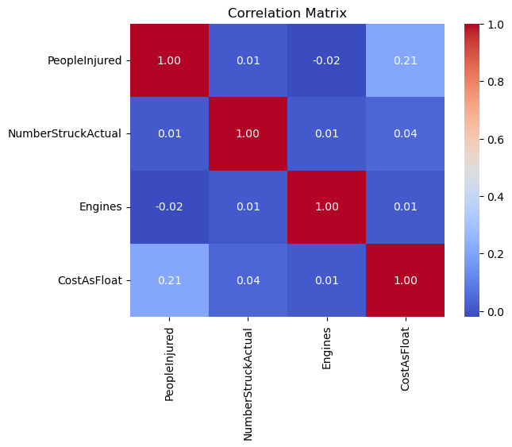

##### Observations

1. Approximately 0.05% of incidents resulted in injuries to people.
2. There is a a weak correlation between "PeopleInjured" and these other factors: "NumberStruckActual", "Engines", "CostAsFloat".
3. Interestingly, the incident that resulted in the highest number of injuries involved small birds.

#### **Correlation**

The data shows little correlation between the fact that people got injured and other factors.

## **7. Limitations and Challenges**

Go to Top

Although the dataset is highly usable and provides valuable insights, there are some gaps that limit a deeper understanding of the trends. For example, we observed an increase in incident occurrences over time, but it's unclear whether this is due to the growing number of planes in operation, urban expansion pushing into bird habitats, or potential changes in aircraft engine design.

While the data offers a strong foundation for analysis, it raises several questions that can only be answered with additional external data. Factors such as the number of aircraft, environmental changes, and even advancements in aviation technology could all influence the trends seen in this dataset. To fully comprehend the underlying causes and patterns, more comprehensive data will be needed to explore these variables in greater detail.

## **8. Applications and Relevance**

Go to Top

### **Research Questions**

The research questions for this project focus on the data, aiming to identify correlations and trends through feature analysis.

#### 2. Flight Phase: During which phases of flight are bird strikes most likely to happen?

Bird strikes are most likely to occur during the Approach phase of flight, where aircraft are generally flying at lower altitudes and are closer to airports, increasing the chances of encountering birds. Interestingly, the data shows that incidents are equally distributed across other flight phases, such as Climb, Landing Roll, and Take-off Run. This suggests that bird strikes are not restricted to a single phase but can occur at various points during the flight. Likely, height during Approach is the cause, due to the proximity to bird habitats around airports.

#### 3. Pilot Awareness: Is there a correlation between pilot awareness of bird strike risks and the severity of incidents?

It does not appear that pilot awareness has a significant proactive effect on the severity of bird strike incidents. The data shows little difference in the severity of incidents between cases where pilots were aware of the bird strike risk and those where they were not. This suggests that, while pilot awareness might be important for preventing some types of incidents, it may not be a decisive factor in minimizing the severity of bird strikes. In fact, damage-causing incidents do not show a marked difference in the Pilot Warned status, implying that other factors, such as the timing or circumstances of the incident, play a more significant role in determining its severity.

#### 4. Model Propensity: Which model has a higher propensity to be implicated in bird strikes?

Aircraft models with two engines have shown a higher tendency to be involved in bird strikes. Specifically, the B-737-700, a popular two-engine model, had the highest number of incidents. This could be due to the large number of these aircraft in operation, as more frequent flights naturally increase the likelihood of encountering bird strikes. However, the higher incidence of bird strikes among two-engine models may also reflect the operational characteristics of these aircraft, such as their flight patterns or altitudes. Despite being a commonly used model, the frequency of bird strikes for these aircraft does not necessarily indicate a design flaw, but rather a statistical outcome of their widespread use.

#### 5. Airport Incidents: Which U.S. airports experience the highest frequency of bird strikes?

The states with the highest frequency of bird strikes are:

```
California: 2,499 incidents
Texas: 2,445 incidents
Florida: 2,045 incidents
```

These states have a significantly higher number of bird strike incidents compared to others. The high frequency in these states can likely be attributed to a combination of factors, including their large air traffic, and larger populations of birds in these regions. Additionally, urban and industrial expansion in these areas may contribute to more frequent encounters between aircraft and birds, especially around airports that are often located in areas close to wildlife habitats.

#### 6. Injury Analysis: What key factors contribute to incidents where people sustain injuries?

While the fact that people sustaining injuries during bird strike incidents warrants attention, the data does not reveal any clear correlation or pattern that suggests a foreseeable solution to mitigate such occurrences. Notably, the incident resulting in the highest number of injuries involved small birds, which challenges the assumption that larger birds pose a greater risk. This suggests that preparing specifically for incidents involving particular bird sizes may not yield significantly better outcomes. Instead, a broader approach to prevention and safety measures might be more effective in addressing the varied nature of these incidents.

### Three key potential use cases for the findings:

#### 1. Airport Wildlife Management

Airports can use the data to enhance wildlife hazard management programs. Understanding that bird strikes are most frequent during the Approach phase allows airports to focus on improving bird deterrent systems and monitoring in these critical areas. Airports could implement more advanced technologies such as radar systems, sonic deterrents, or vegetation management around vulnerable flight paths to reduce the likelihood of bird encounters.

#### 2. Pilot Training Programs

The data showing that pilot awareness does not significantly reduce the severity of incidents suggests a need for better reactive training. Flight schools and airlines could develop bird strike management courses that focus on how to handle incidents when they occur, especially during high-risk phases like approach. The training could also address emergency response protocols and strategies to reduce damage after a bird strike.

#### 3. Aircraft Design and Engineering

Given that two-engine aircraft (e.g., B-737-700) are involved in the most bird strikes, aircraft manufacturers could focus on designing more bird strike-resistant features. For instance, stronger windscreens, more durable engines, and other structural improvements could help reduce the damage from bird strikes. Additionally, examining the engineering needs for popular two-engine models could lead to the development of new systems that better withstand bird collisions.

These use cases focus on improving safety, enhancing operational efficiency, and reducing risks for the aviation industry based on the insights derived from the data.